# Trabajo Práctico - Validación de datos

Gazze Simón - Moresi Manuel

2025-04-20

## Introducción

En el marco de un estudio de investigación clínica multicéntrico, se ha recolectado información a través de un formulario dirigido a mujeres mayores de 18 años con el objetivo de implementar estándares internacionales para el crecimiento fetal. Estos estándares permitirán facilitar la detección temprana de alteraciones en el desarrollo del feto durante la gestación.

Dado que la calidad de los datos es fundamental para garantizar la validez de los resultados en estudios clínicos, en este trabajo nos enfocamos en la validación de la base de datos proveniente del formulario. Nuestra tarea como equipo de análisis estadístico consiste en detectar, clasificar y documentar los errores presentes en los datos recolectados. Esto incluye inconsistencias internas, valores imposibles o improbables, datos faltantes, y cualquier otro tipo de anomalía que pueda comprometer la calidad del estudio.

El formulario es el siguiente:

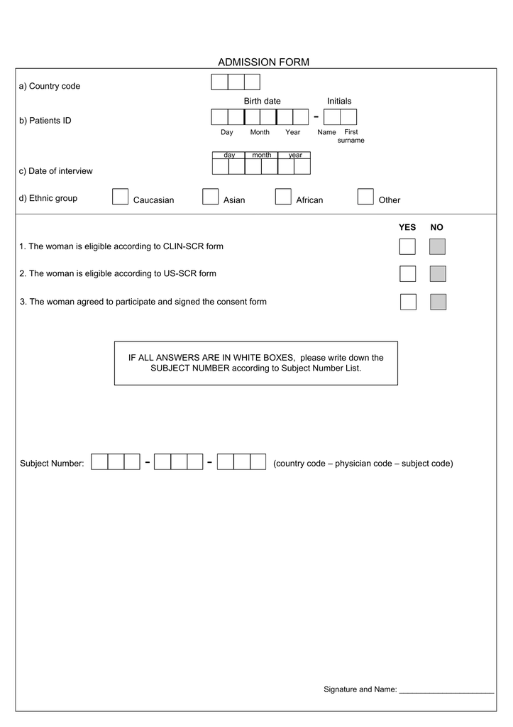

## Objetivo

Llevar a cabo un proceso exhaustivo de validación, empleando técnicas para evaluar la calidad de los datos ingresados y detectar errores sistemáticos en el llenado de los formularios.

## Desarrollo

### 1) Reglas de validación

Las reglas de validación que se plantearan para detectar inconsistencias son las siguientes:

- Se evaluará que las celdas no esten vacias (en caso que corresponda) en cada variable.
- La fecha de entrevista debe seguir el siguiente formato: dd (del 1 al 31)/mm (del 1 al 12)/yyyy (menor a 2025) (*Date of interview*).
- El ID del paciente debe seguir el siguiente formato: dd/mm/yyyy-AA (es decir, *Birth Date + Initials*).
- Las mujeres deben ser mayores de 18 años (18 años *< Date of interview - Birth Date <* 100 años).
- Los códigos de paises posibles en este estudio son: 4, 11, 14, 23, 31, 48, 54, 65, 72, 97 (*Country code* = 4, 11, 14, 23, 31, 48, 54, 65, 72, 97).
- Los grupos étnicos deben ser iguales a 1 = “Caucasico”, 2 = “Asiatico”, 3 = “Africano” o 4 = “Otro” (*Ethnic Group* = 1, 2, 3, 4).
- Las preguntas mencionadas en el formulario como 1, 2 y 3 deben ser iguales a 1 = “No” o 2 = “Si”.
- Si las 3 preguntas anteriores son iguales a 2 = “Si”, entonces el campo *Subject Number* debe contener respuesta, en caso contrario debe dejarse en blanco (**2 condiciones**).
- La respuesta de *Subject Number* debe seguir el siguiente formato: 0 _ _ (*Country code*)_ _ (*Physician code = numeric*) _ _ _ (*Subject code = numeric*).

Y el código para detectar estos errores es el siguiente:

```r
reglas = tribble(
~id, ~descripción, ~condición,
"r1", "(countrycode) es faltante", "is.na(countrycode)",
"r2", "(patientid) es faltante", "is.na(patientid)",
"r3", "(interview) es faltante", "is.na(interview)",
"r4", "(ethnicgroup) es faltante", "is.na(ethnicgroup)",
"r5", "(scr) es faltante", "is.na(scr)",
"r6", "(usscr) es faltante", "is.na(usscr)",
"r7", "(consent) es faltante", "is.na(consent)",
"r8", "(subjectnumber) es faltante cuando (scr), (usscr) y (consent) son 2", "(scr == 2 & usscr == 2 & consent == 2) & (is.na(subjectnumber) | subjectnumber == '')",
"r9", "(ethnicgroup) distinto de 1, 2, 3 o 4", "!is.na(ethnicgroup) & ethnicgroup != '' & !ethnicgroup %in% c(1, 2, 3, 4)",
"r10", "(scr) distinto de 1 o 2", "!is.na(scr) & scr != '' & !scr %in% c(1,2)",
"r11", "(usscr) distinto de 1 o 2", "!is.na(usscr) & usscr != '' & !usscr %in% c(1,2)",
"r12", "(consent) distinto de 1 o 2", "!is.na(consent) & consent != '' & !consent %in% c(1,2)",
"r13", "(countrycode) distinto de 4, 11, 14, 23, 31, 48, 54, 65, 72 o 97", "!is.na(countrycode) & countrycode != '' & !countrycode %in% c(4, 11, 14, 23, 31, 48, 54, 65, 72, 97)",
"r14", "(interview) no sigue formato dd/mm/yyyy", "!is.na(interview) & interview != '' & tryCatch(is.na(as.Date(`interview`, format='%d/%m/%Y')), error = function(e) TRUE)",
"r15", "(patientid) no sigue el formato dd/mm/yyyy-AA", "!is.na(patientid) & patientid != '' & !grepl('^\\\\d{2}/\\\\d{2}/\\\\d{4}-[A-Z]{2}$', patientid) | tryCatch(is.na(as.Date(sub('-.*', '', patientid), format = '%d/%m/%Y')), error = function(e) TRUE)",
"r16", "(subjectnumber) tiene valor cuando (scr), (usscr) o (consent) no son 2", "(scr != 2 | usscr != 2 | consent != 2) & !is.na(subjectnumber) & subjectnumber != ''",
"r17", "(subjectnumber) no respeta formato: 3 dígitos de (countrycode) + 6 números",
"(scr == 2 & usscr == 2 & consent == 2) & !is.na(subjectnumber) & subjectnumber != '' & (!grepl('^\\\\d{9}$', subjectnumber) | substr(subjectnumber, 1, 3) != sprintf('%03d', countrycode))",
"r18", "Edad fuera de rango según (patientid) e (interview)", " !is.na(patientid) & !is.na(interview) &
  tryCatch({
    fecha_nac <- as.Date(sub('-.*', '', patientid), format='%d/%m/%Y')
    fecha_entrevista <- as.Date(interview, format='%d/%m/%Y')
    edad <- as.numeric(difftime(fecha_entrevista, fecha_nac, units = 'days')) / 365.25
    edad < 18 | edad > 100
  }, error = function(e) FALSE)
"
)
```

Cabe destacar que todas las reglas son independientes, y un mismo error no será contado en más de una ocasión.

### 2) Detección de errores

A través de las reglas anteriormente mencionadas, se van a identificar los errores presentes en la base de datos *adm*. Dicha base cuenta con la información referida a 1000 encuestas realizadas.

```r
validador = function(regla, id, condición){
reglas = regla[[condición]]
names(reglas) = regla[[id]]
reglas
}

validar = function(datos, id, validador){
sapply(
validador,
function(x) eval(parse(text = x), datos)
) |>
dplyr::as_tibble() |>
dplyr::mutate(registro = datos[[id]], .before = 0)
}

validacion = validar(adm, "patientid", validador(reglas, "id", "condición"))
inconsistencias = sum(validacion[,2:19],na.rm = T)

datatable(validacion %>% select(1:19) %>% slice(1:1000))
```

|  | registro | r1 | r2 | r3 | r4 | r5 | r6 | r7 | r8 | r9 | r10 | r11 | r12 | r13 | r14 | r15 | r16 | r17 | r18 |
| --- | --- | --- | --- | --- | --- | --- | --- | --- | --- | --- | --- | --- | --- | --- | --- | --- | --- | --- | --- |
| 1 | 15/03/1989-LQ | False | False | False | False | False | False | False | False | False | False | False | False | False | False | False | False | False | False |
| 2 | 19/03/1973-NA | False | False | False | False | False | False | False | False | False | False | False | False | False | False | False | False | False | False |
| 3 | 26/11/1994-CP | False | False | False | False | False | False | False | False | False | False | False | False | False | False | False | False | False | False |
| 4 | 18/04/1990-WX | False | False | False | False | False | False | False | False | False | False | False | False | False | False | False | False | False | False |
| 5 | 01/01/1981-OH | False | False | False | False | False | False | False | False | False | False | False | False | False | False | False | False | False | False |
| 6 | 13/12/1981-NB | False | False | False | False | False | False | False | False | False | False | False | False | False | False | False | False | False | False |
| 7 | 12/07/1977-YO | False | False | False | False | False | False | False | False | False | False | False | False | False | False | False | False | False | False |
| 8 | 12/04/1981-UP | False | False | False | False | False | False | False | False | False | False | False | False | False | False | False | False | True | False |
| 9 | 28/02/1984-SG | False | False | False | False | False | False | False | False | False | False | False | False | False | False | False | True | False | False |
| 10 | 11/11/1990-WP | False | False | False | False | False | False | False | False | False | False | False | False | False | False | False | False | False | False |

[output cut: 990 more lines]

Las celdas con `TRUE` corresponden a errores en esa regla de validación. Además, en la variable `registro` se especifica a que encuestada pertenece. Existen un total de 247 inconsistencias.

### 3) Informe de errores

#### Número de participantes limpios (sin inconsistencias)

```r
validacion_largo = pivot_longer(validacion, -registro, names_to = "regla", values_to = "error")

ind_incos = validacion_largo |>
filter(error) |>
distinct(registro) |>
count()

ind_limp = 1000 - ind_incos
print(paste(ind_limp))
```

```
## [1] "761"
```

Las participantes que no presentan errores en la carga de sus datos son 761.

#### Participantes con inconsistencias

```r
print(paste(ind_incos))
```

```
## [1] "239"
```

Por consecuencia, 239 de las entrevistadas presentan al menos un error en la carga de sus respuestas.

#### Inconsistencias más frecuentes

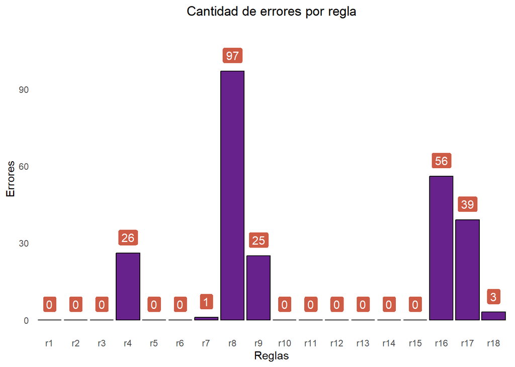

```r
errores = colSums(validacion[,2:19],na.rm = T)
id=reglas$id
df=data.frame(errores,id)

df$id <- factor(df$id, levels = paste0("r", 1:18))

ggplot(data = df) +
  aes(x = id, y = errores) +
  geom_bar(stat = "identity", fill = "darkorchid4", color ="black") +
  geom_label(
    aes(label = errores),
    vjust = -0.5,
    size = 4,
    fill = "coral3",
    color = "white"
    )+
  scale_y_continuous(limits = c(0,110))+
  labs(title = "Cantidad de errores por regla", x = "Reglas", y ="Errores")+
  theme_minimal()+
  theme(plot.title = element_text(hjust = 0.5),
        panel.grid = element_blank())
```

Se evidencian 5 errores que se presentan con mayor frecuencia, estos son:

- La respuesta al campo *Ethnic Group* es distinta a 1, 2, 3 y 4 en 25 ocasiones (**r9**) .
- El campo *Ethnic Group* no contiene respuesta en 26 ocasiones (**r4**).
- El campo *Subject Number* no respeta el formato en 39 ocasiones (**r17**).
- El campo *Subject Number* tiene una respuesta y alguna de las variables filtro (`scr`,`usscr`,`consent`) son distintas de 2 = “Si” en 56 ocasiones (**r16**).
- El campo *Subject Number* no presenta respuesta cuando si debería tenerla , es decir, cuando se cumple que `scr` = 2, `usscr` = 2 y `consent` = 2 en 97 ocasiones (**r8**).

#### Campos con más errores

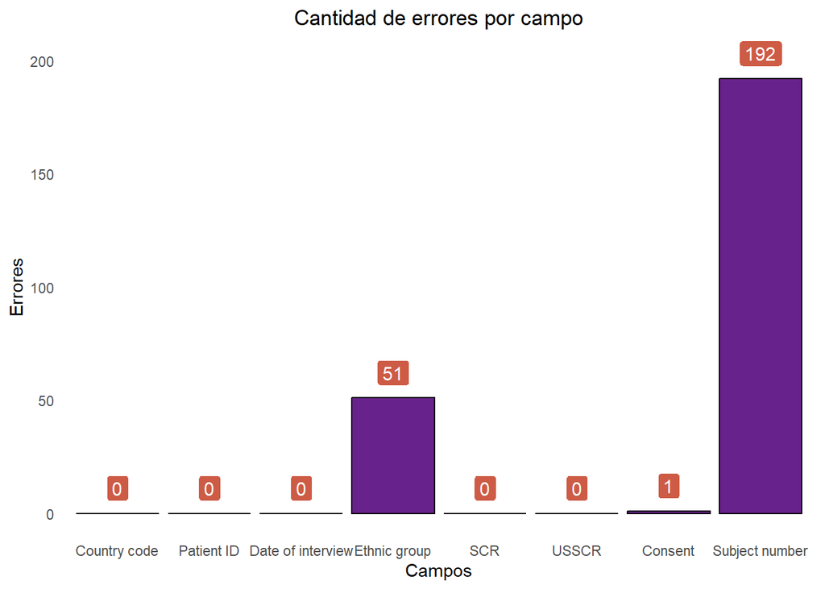

```r
country_code = sum(validacion[,c(2,13)],na.rm = T)
patient_id = sum(validacion[,c(3,15)],na.rm = T)
interview_date = sum(validacion[,c(4,14)],na.rm = T)
ethnic_group = sum(validacion[,c(5,10)],na.rm = T)
scr = sum(validacion[,c(6,11)],na.rm = T)
usscr = sum(validacion[,c(7,12)],na.rm = T)
consent = sum(validacion[,c(8,13)],na.rm = T)
subject_number = sum(validacion[,c(9,17,18)],na.rm = T)

df_2 = data.frame(errores = c(country_code,
                  patient_id,
                  interview_date,
                  ethnic_group,
                  scr,
                  usscr,
                  consent,
                  subject_number))

df_2$campo = c("Country code",
                "Patient ID",
                "Date of interview",
                "Ethnic group",
                "SCR",
                "USSCR",
                "Consent",
                "Subject number")

df_2$campo = factor(df_2$campo, levels = df_2$campo)

ggplot(data = df_2) +
  aes(x = campo, y = errores) +
  geom_bar(stat = "identity", fill = "darkorchid4", color ="black") +
  geom_label(
    aes(label = errores),
    vjust = -0.5,
    size = 4,
    fill = "coral3",
    color = "white"
    )+
  scale_y_continuous(limits = c(0,200))+
  labs(title = "Cantidad de errores por campo", x = "Campos", y ="Errores")+
  theme_minimal()+
  theme(plot.title = element_text(hjust = 0.5),
        panel.grid = element_blank(),
        axis.text.x = element_text(size = 8.5))
```

Los campos que presentan errores son los siguientes:

- *Subject Number* (192 errores)
- *Ethnic Group* (51 errores)
- *Consent* (1 error)

Se recomienda prestar especial atención en los primeros dos campos mencionados, ya que, estos abarcan la gran mayoría de los errores presentes en los datos. Esto podría deberse a que no estan formulados de manera clara.

Por último, se aclara que los errores presentes en la regla 18 (relacionada a que la edad de la participante está fuera de rango) no es tenido en cuenta en este gráfico, ya que no es posible identificar si el error es producido por una mala carga en la fecha de entrevista, en la fecha de nacimiento, o que efectivamente la participante sea menor de edad.

## Anexo

Se detalla el funcionamiento del código de ciertas reglas.

**r14** `!is.na(interview) & interview != '' & tryCatch(is.na(as.Date(interview, format='%d/%m/%Y')),` `error = function(e) TRUE)`

- `!is.na(interview) & interview != ''` se agrega para que no cuente a las celdas vacias, ya que se cuenta en la r3)
- `as.Date` intenta convertir el valor de la variable `interview` en fecha. Hay 3 posibles resultados: si la fecha es correcta convierte en fecha el valor, si la fecha sigue en formato correcto pero no es una fecha real (por ejemplo “32/13/2025”) devuelve un error y si no sigue el formato correcto (por ejemplo “2025-04-15”) da `NA`.
- `is.na` verifica si lo que devuelve `as.Date()` es `NA` y en ese caso da `TRUE`, si devuelve una fecha da `FALSE` y si devuelve un error, sigue manteniendose el error.
- `tryCatch` contempla el caso en el que as.Date da error y devuelve un `TRUE` en ese caso. En caso de que se reciba un TRUE o un `FALSE`, se devuelve el mismo resultado.

**r15** `!is.na(patientid) & patientid != '' & !grepl('\^\\d{2}/\\d{2}/\\d{4}-[A-Z]{2}\$', patientid)` `\| tryCatch(is.na(as.Date(sub('-.\*', '', patientid), format = '%d/%m/%Y')), error = function(e) TRUE)`

- `grepl(pattern,string)` busca si hay coincidencia con un patrón(pattern) dentro de una cadena de texto(string).

**r17** `(scr == 2 & usscr == 2 & consent == 2) & !is.na(subjectnumber) & subjectnumber != ''` `& (!grepl('\^\\\\d{9}\$', subjectnumber) \| substr(subjectnumber, 1, 3) != sprintf('%03d', countrycode))`

- `substr(subjectnumber, 1, 3)` extrae los tres primeros caracteres.
- `sprintf('%03d', countrycode)` convierte el countrycode en texto de 3 dígitos con ceros a la izquierda.